# SQ 016

## Shared Qs (016)

#### Question

1. Let polynomial $p(x)=- x^{4} - 6 x^{3} - 7 x^{2} - 2$.

   Use [synthetic division](https://en.wikipedia.org/wiki/Synthetic_division) to divide $p(x)$ by $x + 5$.

#### Solution

#### Question

2. Let polynomial $p(x)=x^{5} + 2 x^{4} + 4 x^{3} - x^{2} - 4$.

   Use [synthetic division](https://en.wikipedia.org/wiki/Synthetic_division) to divide $p(x)$ by $x + 2$.

#### Solution

#### Question

3. Let polynomial $p(x)=- x^{3} + 3 x^{2} - 4 x$.

   Use [synthetic division](https://en.wikipedia.org/wiki/Synthetic_division) to divide $p(x)$ by $x - 5$.

#### Solution

#### Question

4. Let polynomial $p(x)=x^{4} - 6 x^{3} + 3 x^{2} + 7 x$.

   Use [synthetic division](https://en.wikipedia.org/wiki/Synthetic_division) to divide $p(x)$ by $x - 5$.

#### Solution

#### Question

5. Let polynomial $p(x)=x^{4} + 4 x^{3} - 2 x^{2} - 3 x$.

   Use [synthetic division](https://en.wikipedia.org/wiki/Synthetic_division) to divide $p(x)$ by $x + 4$.

#### Solution

#### Question

6. Let polynomial $p(x)=x^{5} - 5 x^{4} - x^{2} + 6 x + 2$.

   Use [synthetic division](https://en.wikipedia.org/wiki/Synthetic_division) to divide $p(x)$ by $x - 5$.

#### Solution

#### Question

7. Let polynomial $p(x)=x^{4} - 4 x^{3} - 3 x^{2} + 4$.

   Use [synthetic division](https://en.wikipedia.org/wiki/Synthetic_division) to divide $p(x)$ by $x - 5$.

#### Solution

#### Question

8. Let polynomial $p(x)=- x^{5} - 5 x^{4} - 3 x^{3} + 4 x + 2$.

   Use [synthetic division](https://en.wikipedia.org/wiki/Synthetic_division) to divide $p(x)$ by $x + 4$.

#### Solution

#### Question

9. Let polynomial $p(x)=- 3 x^{3} - 4 x^{2} + 7$.

   Use [synthetic division](https://en.wikipedia.org/wiki/Synthetic_division) to divide $p(x)$ by $x + 3$.

#### Solution

#### Question

10. Let polynomial $p(x)=- x^{4} + 7 x^{3} - 7 x^{2} - 4$.

    Use [synthetic division](https://en.wikipedia.org/wiki/Synthetic_division) to divide $p(x)$ by $x - 4$.

#### Solution

#### Question

11. Consider the rational function $f$ defined below in factored form.

    $$f(x) = \frac{-2 x \left(x - 9\right) \left(x - 6\right) \left(x - 1\right) \left(x + 6\right)}{11 x \left(x - 6\right) \left(x + 6\right) \left(x + 7\right)}$$

    Identify the [vertical asymptotes](https://en.wikipedia.org/wiki/Asymptote#Vertical_asymptotes), [zeros](https://en.wikipedia.org/wiki/Zero_of_a_function), and [removable discontinuities](https://en.wikipedia.org/wiki/Classification_of_discontinuities#Removable_discontinuity) (holes).
    - At $x=-7$, there is a
    - At $x=-6$, there is a
    - At $x=0$, there is a
    - At $x=1$, there is a
    - At $x=6$, there is a
    - At $x=9$, there is a
    - Also, is there a horizontal asymptote?

#### Solution

#### Question

12. Consider the rational function $f$ defined below in factored form.

    $$f(x) = \frac{-2 x \left(x + 8\right) \left(x + 9\right)}{7 x \left(x + 4\right) \left(x + 5\right) \left(x + 8\right)}$$

    Identify the [vertical asymptotes](https://en.wikipedia.org/wiki/Asymptote#Vertical_asymptotes), [zeros](https://en.wikipedia.org/wiki/Zero_of_a_function), and [removable discontinuities](https://en.wikipedia.org/wiki/Classification_of_discontinuities#Removable_discontinuity) (holes).
    - At $x=-9$, there is a
    - At $x=-8$, there is a
    - At $x=-5$, there is a
    - At $x=-4$, there is a
    - At $x=0$, there is a
    - Also, is there a horizontal asymptote?

#### Solution

#### Question

13. Consider the rational function $f$ defined below in factored form.

    $$f(x) = \frac{-2 \left(x - 6\right) \left(x - 2\right) \left(x + 8\right)}{11 \left(x - 6\right) \left(x - 2\right) \left(x + 6\right)}$$

    Identify the [vertical asymptotes](https://en.wikipedia.org/wiki/Asymptote#Vertical_asymptotes), [zeros](https://en.wikipedia.org/wiki/Zero_of_a_function), and [removable discontinuities](https://en.wikipedia.org/wiki/Classification_of_discontinuities#Removable_discontinuity) (holes).
    - At $x=-8$, there is a
    - At $x=-6$, there is a
    - At $x=2$, there is a
    - At $x=6$, there is a
    - Also, is there a horizontal asymptote?

#### Solution

#### Question

14. Consider the rational function $f$ defined below in factored form.

    $$f(x) = \frac{-5 \left(x - 8\right) \left(x - 7\right) \left(x - 2\right) \left(x + 9\right)}{2 \left(x - 8\right) \left(x - 2\right) \left(x + 2\right) \left(x + 5\right) \left(x + 9\right)}$$

    Identify the [vertical asymptotes](https://en.wikipedia.org/wiki/Asymptote#Vertical_asymptotes), [zeros](https://en.wikipedia.org/wiki/Zero_of_a_function), and [removable discontinuities](https://en.wikipedia.org/wiki/Classification_of_discontinuities#Removable_discontinuity) (holes).
    - At $x=-9$, there is a
    - At $x=-5$, there is a
    - At $x=-2$, there is a
    - At $x=2$, there is a
    - At $x=7$, there is a
    - At $x=8$, there is a
    - Also, is there a horizontal asymptote?

#### Solution

#### Question

15. Consider the rational function $f$ defined below in factored form.

    $$f(x) = \frac{-5 x \left(x - 5\right) \left(x + 1\right)}{3 \left(x + 1\right) \left(x + 5\right)}$$

    Identify the [vertical asymptotes](https://en.wikipedia.org/wiki/Asymptote#Vertical_asymptotes), [zeros](https://en.wikipedia.org/wiki/Zero_of_a_function), and [removable discontinuities](https://en.wikipedia.org/wiki/Classification_of_discontinuities#Removable_discontinuity) (holes).
    - At $x=-5$, there is a
    - At $x=-1$, there is a
    - At $x=0$, there is a
    - At $x=5$, there is a
    - Also, is there a horizontal asymptote?

#### Solution

#### Question

16. Consider the rational function $f$ defined below in factored form.

    $$f(x) = \frac{7 \left(x - 9\right) \left(x - 2\right) \left(x + 2\right)}{5 x \left(x + 2\right) \left(x + 6\right)}$$

    Identify the [vertical asymptotes](https://en.wikipedia.org/wiki/Asymptote#Vertical_asymptotes), [zeros](https://en.wikipedia.org/wiki/Zero_of_a_function), and [removable discontinuities](https://en.wikipedia.org/wiki/Classification_of_discontinuities#Removable_discontinuity) (holes).
    - At $x=-6$, there is a
    - At $x=-2$, there is a
    - At $x=0$, there is a
    - At $x=2$, there is a
    - At $x=9$, there is a
    - Also, is there a horizontal asymptote?

#### Solution

#### Question

17. Consider the rational function $f$ defined below in factored form.

    $$f(x) = \frac{-3 \left(x - 7\right) \left(x - 4\right) \left(x + 8\right)}{5 \left(x - 7\right) \left(x + 2\right)}$$

    Identify the [vertical asymptotes](https://en.wikipedia.org/wiki/Asymptote#Vertical_asymptotes), [zeros](https://en.wikipedia.org/wiki/Zero_of_a_function), and [removable discontinuities](https://en.wikipedia.org/wiki/Classification_of_discontinuities#Removable_discontinuity) (holes).
    - At $x=-8$, there is a
    - At $x=-2$, there is a
    - At $x=4$, there is a
    - At $x=7$, there is a
    - Also, is there a horizontal asymptote?

#### Solution

#### Question

18. Consider the rational function $f$ defined below in factored form.

    $$f(x) = \frac{7 \left(x - 1\right) \left(x + 7\right)}{3 \left(x - 6\right) \left(x + 3\right) \left(x + 7\right) \left(x + 8\right)}$$

    Identify the [vertical asymptotes](https://en.wikipedia.org/wiki/Asymptote#Vertical_asymptotes), [zeros](https://en.wikipedia.org/wiki/Zero_of_a_function), and [removable discontinuities](https://en.wikipedia.org/wiki/Classification_of_discontinuities#Removable_discontinuity) (holes).
    - At $x=-8$, there is a
    - At $x=-7$, there is a
    - At $x=-3$, there is a
    - At $x=1$, there is a
    - At $x=6$, there is a
    - Also, is there a horizontal asymptote?

#### Solution

#### Question

19. Consider the rational function $f$ defined below in factored form.

    $$f(x) = \frac{-7 \left(x - 8\right) \left(x - 2\right) \left(x + 6\right)}{2 \left(x - 8\right) \left(x - 7\right) \left(x + 7\right)}$$

    Identify the [vertical asymptotes](https://en.wikipedia.org/wiki/Asymptote#Vertical_asymptotes), [zeros](https://en.wikipedia.org/wiki/Zero_of_a_function), and [removable discontinuities](https://en.wikipedia.org/wiki/Classification_of_discontinuities#Removable_discontinuity) (holes).
    - At $x=-7$, there is a
    - At $x=-6$, there is a
    - At $x=2$, there is a
    - At $x=7$, there is a
    - At $x=8$, there is a
    - Also, is there a horizontal asymptote?

#### Solution

#### Question

20. Consider the rational function $f$ defined below in factored form.

    $$f(x) = \frac{2 \left(x + 1\right) \left(x + 5\right)}{11 \left(x + 5\right) \left(x + 8\right)}$$

    Identify the [vertical asymptotes](https://en.wikipedia.org/wiki/Asymptote#Vertical_asymptotes), [zeros](https://en.wikipedia.org/wiki/Zero_of_a_function), and [removable discontinuities](https://en.wikipedia.org/wiki/Classification_of_discontinuities#Removable_discontinuity) (holes).
    - At $x=-8$, there is a
    - At $x=-5$, there is a
    - At $x=-1$, there is a
    - Also, is there a horizontal asymptote?

#### Solution

#### Question

21. The quadratic formula states:
    - If $ax^2+bx+c=0$ then:
      $$x = \frac{-b\pm\sqrt{b^2-4ac}}{2a}$$

    Use the quadratic formula to solve the quadratic equation:
    $$21x^2+58x+21=0$$
    1. -7/3
    2. -3/2
    3. -7/5
    4. -3/7
    5. 3/7
    6. 7/5
    7. 3/2
    8. 7/3

#### Solution

#### Question

22. The quadratic formula states:
    - If $ax^2+bx+c=0$ then:
      $$x = \frac{-b\pm\sqrt{b^2-4ac}}{2a}$$

    Use the quadratic formula to solve the quadratic equation:
    $$4x^2-8x-21=0$$
    1. -7/2
    2. -3/2
    3. -3/5
    4. -3/7
    5. 3/7
    6. 3/5
    7. 3/2
    8. 7/2

#### Solution

#### Question

23. The quadratic formula states:
    - If $ax^2+bx+c=0$ then:
      $$x = \frac{-b\pm\sqrt{b^2-4ac}}{2a}$$

    Use the quadratic formula to solve the quadratic equation:
    $$6x^2+23x+21=0$$
    1. -7/3
    2. -3/2
    3. -3/5
    4. -2/5
    5. 2/5
    6. 3/5
    7. 3/2
    8. 7/3

#### Solution

#### Question

24. The quadratic formula states:
    - If $ax^2+bx+c=0$ then:
      $$x = \frac{-b\pm\sqrt{b^2-4ac}}{2a}$$

    Use the quadratic formula to solve the quadratic equation:
    $$35x^2+4x-4=0$$
    1. -7/3
    2. -3/2
    3. -2/5
    4. -2/7
    5. 2/7
    6. 2/5
    7. 3/2
    8. 7/3

#### Solution

#### Question

25. The quadratic formula states:
    - If $ax^2+bx+c=0$ then:
      $$x = \frac{-b\pm\sqrt{b^2-4ac}}{2a}$$

    Use the quadratic formula to solve the quadratic equation:
    $$6x^2-19x+10=0$$
    1. -7/2
    2. -5/2
    3. -5/7
    4. -2/3
    5. 2/3
    6. 5/7
    7. 5/2
    8. 7/2

#### Solution

#### Question

26. The quadratic formula states:
    - If $ax^2+bx+c=0$ then:
      $$x = \frac{-b\pm\sqrt{b^2-4ac}}{2a}$$

    Use the quadratic formula to solve the quadratic equation:
    $$21x^2-8x-4=0$$
    1. -5/7
    2. -2/3
    3. -2/5
    4. -2/7
    5. 2/7
    6. 2/5
    7. 2/3
    8. 5/7

#### Solution

#### Question

27. The quadratic formula states:
    - If $ax^2+bx+c=0$ then:
      $$x = \frac{-b\pm\sqrt{b^2-4ac}}{2a}$$

    Use the quadratic formula to solve the quadratic equation:
    $$49x^2-14x-15=0$$
    1. -5/7
    2. -3/5
    3. -3/7
    4. -2/7
    5. 2/7
    6. 3/7
    7. 3/5
    8. 5/7

#### Solution

#### Question

28. The quadratic formula states:
    - If $ax^2+bx+c=0$ then:
      $$x = \frac{-b\pm\sqrt{b^2-4ac}}{2a}$$

    Use the quadratic formula to solve the quadratic equation:
    $$35x^2-46x+15=0$$
    1. -5/7
    2. -2/3
    3. -3/5
    4. -2/7
    5. 2/7
    6. 3/5
    7. 2/3
    8. 5/7

#### Solution

#### Question

29. The quadratic formula states:
    - If $ax^2+bx+c=0$ then:
      $$x = \frac{-b\pm\sqrt{b^2-4ac}}{2a}$$

    Use the quadratic formula to solve the quadratic equation:
    $$35x^2+59x+14=0$$
    1. -5/3
    2. -7/5
    3. -5/7
    4. -2/7
    5. 2/7
    6. 5/7
    7. 7/5
    8. 5/3

#### Solution

#### Question

30. The quadratic formula states:
    - If $ax^2+bx+c=0$ then:
      $$x = \frac{-b\pm\sqrt{b^2-4ac}}{2a}$$

    Use the quadratic formula to solve the quadratic equation:
    $$10x^2-19x+6=0$$
    1. -7/3
    2. -3/2
    3. -5/7
    4. -2/5
    5. 2/5
    6. 5/7
    7. 3/2
    8. 7/3

#### Solution

#### Question

31. The quadratic formula says if $ax^2+bx+c=0$ then $x=\frac{-b\pm\sqrt{b^2-4ac}}{2a}$.

    The radicand is called the [discriminant](https://en.wikipedia.org/wiki/Discriminant#Degree_2). When $b^2-4ac<0$ then the solutions are [complex](https://en.wikipedia.org/wiki/Complex_number). When a quadratic equation has complex solutions, those solutions are always [complex conjugates](https://en.wikipedia.org/wiki/Complex_conjugate).

    Use the quadratic formula to solve

    $$x^2+12x+37=0$$

#### Solution

#### Question

32. The quadratic formula says if $ax^2+bx+c=0$ then $x=\frac{-b\pm\sqrt{b^2-4ac}}{2a}$.

    The radicand is called the [discriminant](https://en.wikipedia.org/wiki/Discriminant#Degree_2). When $b^2-4ac<0$ then the solutions are [complex](https://en.wikipedia.org/wiki/Complex_number). When a quadratic equation has complex solutions, those solutions are always [complex conjugates](https://en.wikipedia.org/wiki/Complex_conjugate).

    Use the quadratic formula to solve

    $$x^2+8x+25=0$$

    *Remember:* $i=\sqrt{-1}$.
    1. 3-4i
    2. -4+3i
    3. 4-3i
    4. -4-3i
    5. -3-4i
    6. 4+3i
    7. -3+4i
    8. 3+4i

#### Solution

#### Question

33. The quadratic formula says if $ax^2+bx+c=0$ then $x=\frac{-b\pm\sqrt{b^2-4ac}}{2a}$.

    The radicand is called the [discriminant](https://en.wikipedia.org/wiki/Discriminant#Degree_2). When $b^2-4ac<0$ then the solutions are [complex](https://en.wikipedia.org/wiki/Complex_number). When a quadratic equation has complex solutions, those solutions are always [complex conjugates](https://en.wikipedia.org/wiki/Complex_conjugate).

    Use the quadratic formula to solve

    $$x^2-8x+20=0$$

    *Remember:* $i=\sqrt{-1}$.
    1. 2-4i
    2. 2+4i
    3. -2-4i
    4. -4+2i
    5. -2+4i
    6. -4-2i
    7. 4+2i
    8. 4-2i

#### Solution

#### Question

34. The quadratic formula says if $ax^2+bx+c=0$ then $x=\frac{-b\pm\sqrt{b^2-4ac}}{2a}$.

    The radicand is called the [discriminant](https://en.wikipedia.org/wiki/Discriminant#Degree_2). When $b^2-4ac<0$ then the solutions are [complex](https://en.wikipedia.org/wiki/Complex_number). When a quadratic equation has complex solutions, those solutions are always [complex conjugates](https://en.wikipedia.org/wiki/Complex_conjugate).

    Use the quadratic formula to solve

    $$x^2+4x+20=0$$

    *Remember:* $i=\sqrt{-1}$.
    1. 4+2i
    2. 4-2i
    3. 2+4i
    4. 2-4i
    5. -2+4i
    6. -4-2i
    7. -4+2i
    8. -2-4i

#### Solution

#### Question

35. The quadratic formula says if $ax^2+bx+c=0$ then $x=\frac{-b\pm\sqrt{b^2-4ac}}{2a}$.

    The radicand is called the [discriminant](https://en.wikipedia.org/wiki/Discriminant#Degree_2). When $b^2-4ac<0$ then the solutions are [complex](https://en.wikipedia.org/wiki/Complex_number). When a quadratic equation has complex solutions, those solutions are always [complex conjugates](https://en.wikipedia.org/wiki/Complex_conjugate).

    Use the quadratic formula to solve

    $$x^2-8x+17=0$$

#### Solution

#### Question

36. The quadratic formula says if $ax^2+bx+c=0$ then $x=\frac{-b\pm\sqrt{b^2-4ac}}{2a}$.

    The radicand is called the [discriminant](https://en.wikipedia.org/wiki/Discriminant#Degree_2). When $b^2-4ac<0$ then the solutions are [complex](https://en.wikipedia.org/wiki/Complex_number). When a quadratic equation has complex solutions, those solutions are always [complex conjugates](https://en.wikipedia.org/wiki/Complex_conjugate).

    Use the quadratic formula to solve

    $$x^2+8x+41=0$$

    *Remember:* $i=\sqrt{-1}$.
    1. -5-4i
    2. 4-5i
    3. 5-4i
    4. -4-5i
    5. 4+5i
    6. -4+5i
    7. -5+4i
    8. 5+4i

#### Solution

#### Question

37. The quadratic formula says if $ax^2+bx+c=0$ then $x=\frac{-b\pm\sqrt{b^2-4ac}}{2a}$.

    The radicand is called the [discriminant](https://en.wikipedia.org/wiki/Discriminant#Degree_2). When $b^2-4ac<0$ then the solutions are [complex](https://en.wikipedia.org/wiki/Complex_number). When a quadratic equation has complex solutions, those solutions are always [complex conjugates](https://en.wikipedia.org/wiki/Complex_conjugate).

    Use the quadratic formula to solve

    $$x^2-10x+26=0$$

#### Solution

#### Question

38. The quadratic formula says if $ax^2+bx+c=0$ then $x=\frac{-b\pm\sqrt{b^2-4ac}}{2a}$.

    The radicand is called the [discriminant](https://en.wikipedia.org/wiki/Discriminant#Degree_2). When $b^2-4ac<0$ then the solutions are [complex](https://en.wikipedia.org/wiki/Complex_number). When a quadratic equation has complex solutions, those solutions are always [complex conjugates](https://en.wikipedia.org/wiki/Complex_conjugate).

    Use the quadratic formula to solve

    $$x^2-6x+45=0$$

    *Remember:* $i=\sqrt{-1}$.
    1. 6+3i
    2. 6-3i
    3. -6+3i
    4. -3+6i
    5. 3-6i
    6. 3+6i
    7. -6-3i
    8. -3-6i

#### Solution

#### Question

39. The quadratic formula says if $ax^2+bx+c=0$ then $x=\frac{-b\pm\sqrt{b^2-4ac}}{2a}$.

    The radicand is called the [discriminant](https://en.wikipedia.org/wiki/Discriminant#Degree_2). When $b^2-4ac<0$ then the solutions are [complex](https://en.wikipedia.org/wiki/Complex_number). When a quadratic equation has complex solutions, those solutions are always [complex conjugates](https://en.wikipedia.org/wiki/Complex_conjugate).

    Use the quadratic formula to solve

    $$x^2+8x+52=0$$

    *Remember:* $i=\sqrt{-1}$.
    1. 4-6i
    2. -6-4i
    3. 6+4i
    4. -4-6i
    5. 4+6i
    6. -4+6i
    7. 6-4i
    8. -6+4i

#### Solution

#### Question

40. The quadratic formula says if $ax^2+bx+c=0$ then $x=\frac{-b\pm\sqrt{b^2-4ac}}{2a}$.

    The radicand is called the [discriminant](https://en.wikipedia.org/wiki/Discriminant#Degree_2). When $b^2-4ac<0$ then the solutions are [complex](https://en.wikipedia.org/wiki/Complex_number). When a quadratic equation has complex solutions, those solutions are always [complex conjugates](https://en.wikipedia.org/wiki/Complex_conjugate).

    Use the quadratic formula to solve

    $$x^2-12x+40=0$$

    *Remember:* $i=\sqrt{-1}$.
    1. -2-6i
    2. 2+6i
    3. 2-6i
    4. -6-2i
    5. 6-2i
    6. 6+2i
    7. -2+6i
    8. -6+2i

#### Solution

#### Question

41. Factor the cubic polynomial $x^{3} + 9 x^{2} + 24 x + 16$ to find solutions to the cubic equation:
    $$x^{3} + 9 x^{2} + 24 x + 16=0$$

    *Hint: all solutions are integers between -6 and 6*.

    You might find the [rational root theorem](https://en.wikipedia.org/wiki/Rational_root_theorem) helpful. I’d recommend using [synthetic division](https://en.wikipedia.org/wiki/Synthetic_division) to check your guesses until you find one linear factor, then you’ll just need to factor the quadratic factor into two linear factors.
    1. -6
    2. -5
    3. -4
    4. -3
    5. -2
    6. -1
    7. 0
    8. 1
    9. 2
    10. 3
    11. 4
    12. 5
    13. 6

#### Solution

#### Question

42. Factor the cubic polynomial $x^{3} + 3 x^{2} - 36 x - 108$ to find solutions to the cubic equation:
    $$x^{3} + 3 x^{2} - 36 x - 108=0$$

    *Hint: all solutions are integers between -6 and 6*.

    You might find the [rational root theorem](https://en.wikipedia.org/wiki/Rational_root_theorem) helpful. I’d recommend using [synthetic division](https://en.wikipedia.org/wiki/Synthetic_division) to check your guesses until you find one linear factor, then you’ll just need to factor the quadratic factor into two linear factors.
    1. -6
    2. -5
    3. -4
    4. -3
    5. -2
    6. -1
    7. 0
    8. 1
    9. 2
    10. 3
    11. 4
    12. 5
    13. 6

#### Solution

#### Question

43. Factor the cubic polynomial $x^{3} - 5 x^{2} - 4 x + 20$ to find solutions to the cubic equation:
    $$x^{3} - 5 x^{2} - 4 x + 20=0$$

    *Hint: all solutions are integers between -6 and 6*.

    You might find the [rational root theorem](https://en.wikipedia.org/wiki/Rational_root_theorem) helpful. I’d recommend using [synthetic division](https://en.wikipedia.org/wiki/Synthetic_division) to check your guesses until you find one linear factor, then you’ll just need to factor the quadratic factor into two linear factors.
    1. -6
    2. -5
    3. -4
    4. -3
    5. -2
    6. -1
    7. 0
    8. 1
    9. 2
    10. 3
    11. 4
    12. 5
    13. 6

#### Solution

#### Question

44. Factor the cubic polynomial $x^{3} + x^{2} - 16 x - 16$ to find solutions to the cubic equation:
    $$x^{3} + x^{2} - 16 x - 16=0$$

    *Hint: all solutions are integers between -6 and 6*.

    You might find the [rational root theorem](https://en.wikipedia.org/wiki/Rational_root_theorem) helpful. I’d recommend using [synthetic division](https://en.wikipedia.org/wiki/Synthetic_division) to check your guesses until you find one linear factor, then you’ll just need to factor the quadratic factor into two linear factors.
    1. -6
    2. -5
    3. -4
    4. -3
    5. -2
    6. -1
    7. 0
    8. 1
    9. 2
    10. 3
    11. 4
    12. 5
    13. 6

#### Solution

#### Question

45. Factor the cubic polynomial $x^{3} - 12 x^{2} + 41 x - 30$ to find solutions to the cubic equation:
    $$x^{3} - 12 x^{2} + 41 x - 30=0$$

    *Hint: all solutions are integers between -6 and 6*.

    You might find the [rational root theorem](https://en.wikipedia.org/wiki/Rational_root_theorem) helpful. I’d recommend using [synthetic division](https://en.wikipedia.org/wiki/Synthetic_division) to check your guesses until you find one linear factor, then you’ll just need to factor the quadratic factor into two linear factors.
    1. -6
    2. -5
    3. -4
    4. -3
    5. -2
    6. -1
    7. 0
    8. 1
    9. 2
    10. 3
    11. 4
    12. 5
    13. 6

#### Solution

#### Question

46. Factor the cubic polynomial $x^{3} + 4 x^{2} - x - 4$ to find solutions to the cubic equation:
    $$x^{3} + 4 x^{2} - x - 4=0$$

    *Hint: all solutions are integers between -6 and 6*.

    You might find the [rational root theorem](https://en.wikipedia.org/wiki/Rational_root_theorem) helpful. I’d recommend using [synthetic division](https://en.wikipedia.org/wiki/Synthetic_division) to check your guesses until you find one linear factor, then you’ll just need to factor the quadratic factor into two linear factors.
    1. -6
    2. -5
    3. -4
    4. -3
    5. -2
    6. -1
    7. 0
    8. 1
    9. 2
    10. 3
    11. 4
    12. 5
    13. 6

#### Solution

#### Question

47. Factor the cubic polynomial $x^{3} - 7 x^{2} - 24 x + 180$ to find solutions to the cubic equation:
    $$x^{3} - 7 x^{2} - 24 x + 180=0$$

    *Hint: all solutions are integers between -6 and 6*.

    You might find the [rational root theorem](https://en.wikipedia.org/wiki/Rational_root_theorem) helpful. I’d recommend using [synthetic division](https://en.wikipedia.org/wiki/Synthetic_division) to check your guesses until you find one linear factor, then you’ll just need to factor the quadratic factor into two linear factors.
    1. -6
    2. -5
    3. -4
    4. -3
    5. -2
    6. -1
    7. 0
    8. 1
    9. 2
    10. 3
    11. 4
    12. 5
    13. 6

#### Solution

#### Question

48. Factor the cubic polynomial $x^{3} - 6 x^{2} - 4 x + 24$ to find solutions to the cubic equation:
    $$x^{3} - 6 x^{2} - 4 x + 24=0$$

    *Hint: all solutions are integers between -6 and 6*.

    You might find the [rational root theorem](https://en.wikipedia.org/wiki/Rational_root_theorem) helpful. I’d recommend using [synthetic division](https://en.wikipedia.org/wiki/Synthetic_division) to check your guesses until you find one linear factor, then you’ll just need to factor the quadratic factor into two linear factors.
    1. -6
    2. -5
    3. -4
    4. -3
    5. -2
    6. -1
    7. 0
    8. 1
    9. 2
    10. 3
    11. 4
    12. 5
    13. 6

#### Solution

#### Question

49. Factor the cubic polynomial $x^{3} - 2 x^{2} - x + 2$ to find solutions to the cubic equation:
    $$x^{3} - 2 x^{2} - x + 2=0$$

    *Hint: all solutions are integers between -6 and 6*.

    You might find the [rational root theorem](https://en.wikipedia.org/wiki/Rational_root_theorem) helpful. I’d recommend using [synthetic division](https://en.wikipedia.org/wiki/Synthetic_division) to check your guesses until you find one linear factor, then you’ll just need to factor the quadratic factor into two linear factors.
    1. -6
    2. -5
    3. -4
    4. -3
    5. -2
    6. -1
    7. 0
    8. 1
    9. 2
    10. 3
    11. 4
    12. 5
    13. 6

#### Solution

#### Question

50. Factor the cubic polynomial $x^{3} - x^{2} - 4 x + 4$ to find solutions to the cubic equation:
    $$x^{3} - x^{2} - 4 x + 4=0$$

    *Hint: all solutions are integers between -6 and 6*.

    You might find the [rational root theorem](https://en.wikipedia.org/wiki/Rational_root_theorem) helpful. I’d recommend using [synthetic division](https://en.wikipedia.org/wiki/Synthetic_division) to check your guesses until you find one linear factor, then you’ll just need to factor the quadratic factor into two linear factors.
    1. -6
    2. -5
    3. -4
    4. -3
    5. -2
    6. -1
    7. 0
    8. 1
    9. 2
    10. 3
    11. 4
    12. 5
    13. 6

#### Solution

#### Question

51. Solve:

    $$x^3-2x^2+5x+26=0$$
    - The real solution:
    - The first complex solution: -$i$
    - The other complex solution: +$i$

    *Hint: the real solution is an integer between -6 and 6. Also the [rational root theorem](https://en.wikipedia.org/wiki/Rational_root_theorem) places additional constraints on possible real solutions. [Descarte’s rule of signs](https://en.wikipedia.org/wiki/Descartes%27_rule_of_signs) can also help eliminate possibilities.*

#### Solution

#### Question

52. Solve:

    $$x^3-11x^2+99x-89=0$$
    - The real solution:
    - The first complex solution: -$i$
    - The other complex solution: +$i$

    *Hint: the real solution is an integer between -6 and 6. Also the [rational root theorem](https://en.wikipedia.org/wiki/Rational_root_theorem) places additional constraints on possible real solutions. [Descarte’s rule of signs](https://en.wikipedia.org/wiki/Descartes%27_rule_of_signs) can also help eliminate possibilities.*

#### Solution

#### Question

53. Solve:

    $$x^3+3x^2+67x+65=0$$
    - The real solution:
    - The first complex solution: -$i$
    - The other complex solution: +$i$

    *Hint: the real solution is an integer between -6 and 6. Also the [rational root theorem](https://en.wikipedia.org/wiki/Rational_root_theorem) places additional constraints on possible real solutions. [Descarte’s rule of signs](https://en.wikipedia.org/wiki/Descartes%27_rule_of_signs) can also help eliminate possibilities.*

#### Solution

#### Question

54. Solve:

    $$x^3+3x^2-54=0$$
    - The real solution:
    - The first complex solution: -$i$
    - The other complex solution: +$i$

    *Hint: the real solution is an integer between -6 and 6. Also the [rational root theorem](https://en.wikipedia.org/wiki/Rational_root_theorem) places additional constraints on possible real solutions. [Descarte’s rule of signs](https://en.wikipedia.org/wiki/Descartes%27_rule_of_signs) can also help eliminate possibilities.*

#### Solution

#### Question

55. Solve:

    $$x^3-7x^2+72x+80=0$$
    - The real solution:
    - The first complex solution: -$i$
    - The other complex solution: +$i$

    *Hint: the real solution is an integer between -6 and 6. Also the [rational root theorem](https://en.wikipedia.org/wiki/Rational_root_theorem) places additional constraints on possible real solutions. [Descarte’s rule of signs](https://en.wikipedia.org/wiki/Descartes%27_rule_of_signs) can also help eliminate possibilities.*

#### Solution

#### Question

56. Solve:

    $$x^3+14x^2+69x+90=0$$
    - The real solution:
    - The first complex solution: -$i$
    - The other complex solution: +$i$

    *Hint: the real solution is an integer between -6 and 6. Also the [rational root theorem](https://en.wikipedia.org/wiki/Rational_root_theorem) places additional constraints on possible real solutions. [Descarte’s rule of signs](https://en.wikipedia.org/wiki/Descartes%27_rule_of_signs) can also help eliminate possibilities.*

#### Solution

#### Question

57. Solve:

    $$x^3+13x+34=0$$
    - The real solution:
    - The first complex solution: -$i$
    - The other complex solution: +$i$

    *Hint: the real solution is an integer between -6 and 6. Also the [rational root theorem](https://en.wikipedia.org/wiki/Rational_root_theorem) places additional constraints on possible real solutions. [Descarte’s rule of signs](https://en.wikipedia.org/wiki/Descartes%27_rule_of_signs) can also help eliminate possibilities.*

#### Solution

#### Question

58. Solve:

    $$x^3+9x^2+25x+17=0$$
    - The real solution:
    - The first complex solution: -$i$
    - The other complex solution: +$i$

    *Hint: the real solution is an integer between -6 and 6. Also the [rational root theorem](https://en.wikipedia.org/wiki/Rational_root_theorem) places additional constraints on possible real solutions. [Descarte’s rule of signs](https://en.wikipedia.org/wiki/Descartes%27_rule_of_signs) can also help eliminate possibilities.*

#### Solution

#### Question

59. Solve:

    $$x^3+9x^2+16x-26=0$$
    - The real solution:
    - The first complex solution: -$i$
    - The other complex solution: +$i$

    *Hint: the real solution is an integer between -6 and 6. Also the [rational root theorem](https://en.wikipedia.org/wiki/Rational_root_theorem) places additional constraints on possible real solutions. [Descarte’s rule of signs](https://en.wikipedia.org/wiki/Descartes%27_rule_of_signs) can also help eliminate possibilities.*

#### Solution

#### Question

60. Solve:

    $$x^3-17x^2+79x+97=0$$
    - The real solution:
    - The first complex solution: -$i$
    - The other complex solution: +$i$

    *Hint: the real solution is an integer between -6 and 6. Also the [rational root theorem](https://en.wikipedia.org/wiki/Rational_root_theorem) places additional constraints on possible real solutions. [Descarte’s rule of signs](https://en.wikipedia.org/wiki/Descartes%27_rule_of_signs) can also help eliminate possibilities.*

#### Solution

#### Question

61. $$f(x) = -5x^5-10x^4+4x^3+10x^2-3x-8$$

### Your answers:

    - Left end behavior: $\lim\limits_{x\to-\infty}f(x)=$
    - Right end behavior: $\lim\limits_{x\to\infty}f(x)=$

#### Solution

#### Question

62. $$f(x) = -2x^8+10x^7+7x^6+4x^5-6x^4+3x^3-5x^2+2x-8$$

### Your answers:

    - Left end behavior: $\lim\limits_{x\to-\infty}f(x)=$
    - Right end behavior: $\lim\limits_{x\to\infty}f(x)=$

#### Solution

#### Question

63. $$f(x) = -8x^5+4x^4-5x^3-7x^2-4x+6$$

### Your answers:

    - Left end behavior: $\lim\limits_{x\to-\infty}f(x)=$
    - Right end behavior: $\lim\limits_{x\to\infty}f(x)=$

#### Solution

#### Question

64. $$f(x) = -9x^7+9x^6-6x^5+3x^4-5x^3-2x^2+10x+4$$

### Your answers:

    - Left end behavior: $\lim\limits_{x\to-\infty}f(x)=$
    - Right end behavior: $\lim\limits_{x\to\infty}f(x)=$

#### Solution

#### Question

65. $$f(x) = 9x^6+5x^5+4x^4-3x^3-10x^2-8x-6$$

### Your answers:

    - Left end behavior: $\lim\limits_{x\to-\infty}f(x)=$
    - Right end behavior: $\lim\limits_{x\to\infty}f(x)=$

#### Solution

#### Question

66. $$f(x) = 9x^7-3x^6+7x^5+4x^4-6x^3+5x^2-9x+10$$

### Your answers:

    - Left end behavior: $\lim\limits_{x\to-\infty}f(x)=$
    - Right end behavior: $\lim\limits_{x\to\infty}f(x)=$

#### Solution

#### Question

67. $$f(x) = 2x^5-7x^4+5x^3-6x^2-2x-3$$

### Your answers:

    - Left end behavior: $\lim\limits_{x\to-\infty}f(x)=$
    - Right end behavior: $\lim\limits_{x\to\infty}f(x)=$

#### Solution

#### Question

68. $$f(x) = 2x^5+3x^4-8x^3-7x^2+10x+5$$

### Your answers:

    - Left end behavior: $\lim\limits_{x\to-\infty}f(x)=$
    - Right end behavior: $\lim\limits_{x\to\infty}f(x)=$

#### Solution

#### Question

69. $$f(x) = 7x^5-7x^4-2x^3+3x^2-4x+10$$

### Your answers:

    - Left end behavior: $\lim\limits_{x\to-\infty}f(x)=$
    - Right end behavior: $\lim\limits_{x\to\infty}f(x)=$

#### Solution

#### Question

70. $$f(x) = -3x^8+10x^7-7x^6+9x^5+7x^4+3x^3+6x^2+2x-5$$

### Your answers:

    - Left end behavior: $\lim\limits_{x\to-\infty}f(x)=$
    - Right end behavior: $\lim\limits_{x\to\infty}f(x)=$

#### Solution

#### Question

71. Let $z_1$ and $z_2$ be two [complex numbers](https://en.wikipedia.org/wiki/Complex_number).
    $$z_1 = -9+9i$$
    $$z_2 = 4+3i$$
    Find the sum.
    $$z_1+z_2 = ~?$$

    *Type your answer precisely, with no spaces, using digits, “-”, “+”, and “i”. If the real term is nonzero, put it first. If either component is zero, do not include that term. If both components are zero, type “0” without the quotes. Instead of writing “1i” or “-1i” just write “i” or “-i”.*

#### Solution

#### Question

72. Let $z_1$ and $z_2$ be two [complex numbers](https://en.wikipedia.org/wiki/Complex_number).
    $$z_1 = 4-8i$$
    $$z_2 = -1-5i$$
    Find the sum.
    $$z_1+z_2 = ~?$$

    *Type your answer precisely, with no spaces, using digits, “-”, “+”, and “i”. If the real term is nonzero, put it first. If either component is zero, do not include that term. If both components are zero, type “0” without the quotes. Instead of writing “1i” or “-1i” just write “i” or “-i”.*

#### Solution

#### Question

73. Let $z_1$ and $z_2$ be two [complex numbers](https://en.wikipedia.org/wiki/Complex_number).
    $$z_1 = -1-3i$$
    $$z_2 = 4-3i$$
    Find the sum.
    $$z_1+z_2 = ~?$$

    *Type your answer precisely, with no spaces, using digits, “-”, “+”, and “i”. If the real term is nonzero, put it first. If either component is zero, do not include that term. If both components are zero, type “0” without the quotes. Instead of writing “1i” or “-1i” just write “i” or “-i”.*

#### Solution

#### Question

74. Let $z_1$ and $z_2$ be two [complex numbers](https://en.wikipedia.org/wiki/Complex_number).
    $$z_1 = -1+8i$$
    $$z_2 = -8+2i$$
    Find the sum.
    $$z_1+z_2 = ~?$$

    *Type your answer precisely, with no spaces, using digits, “-”, “+”, and “i”. If the real term is nonzero, put it first. If either component is zero, do not include that term. If both components are zero, type “0” without the quotes. Instead of writing “1i” or “-1i” just write “i” or “-i”.*

#### Solution

#### Question

75. Let $z_1$ and $z_2$ be two [complex numbers](https://en.wikipedia.org/wiki/Complex_number).
    $$z_1 = 2-3i$$
    $$z_2 = -5-3i$$
    Find the sum.
    $$z_1+z_2 = ~?$$

    *Type your answer precisely, with no spaces, using digits, “-”, “+”, and “i”. If the real term is nonzero, put it first. If either component is zero, do not include that term. If both components are zero, type “0” without the quotes. Instead of writing “1i” or “-1i” just write “i” or “-i”.*

#### Solution

#### Question

76. Let $z_1$ and $z_2$ be two [complex numbers](https://en.wikipedia.org/wiki/Complex_number).
    $$z_1 = 2-8i$$
    $$z_2 = -3-6i$$
    Find the sum.
    $$z_1+z_2 = ~?$$

    *Type your answer precisely, with no spaces, using digits, “-”, “+”, and “i”. If the real term is nonzero, put it first. If either component is zero, do not include that term. If both components are zero, type “0” without the quotes. Instead of writing “1i” or “-1i” just write “i” or “-i”.*

#### Solution

#### Question

77. Let $z_1$ and $z_2$ be two [complex numbers](https://en.wikipedia.org/wiki/Complex_number).
    $$z_1 = -7-2i$$
    $$z_2 = 7+3i$$
    Find the sum.
    $$z_1+z_2 = ~?$$

    *Type your answer precisely, with no spaces, using digits, “-”, “+”, and “i”. If the real term is nonzero, put it first. If either component is zero, do not include that term. If both components are zero, type “0” without the quotes. Instead of writing “1i” or “-1i” just write “i” or “-i”.*

#### Solution

#### Question

78. Let $z_1$ and $z_2$ be two [complex numbers](https://en.wikipedia.org/wiki/Complex_number).
    $$z_1 = 3-6i$$
    $$z_2 = -7+4i$$
    Find the sum.
    $$z_1+z_2 = ~?$$

    *Type your answer precisely, with no spaces, using digits, “-”, “+”, and “i”. If the real term is nonzero, put it first. If either component is zero, do not include that term. If both components are zero, type “0” without the quotes. Instead of writing “1i” or “-1i” just write “i” or “-i”.*

#### Solution

#### Question

79. Let $z_1$ and $z_2$ be two [complex numbers](https://en.wikipedia.org/wiki/Complex_number).
    $$z_1 = -7+2i$$
    $$z_2 = -5-i$$
    Find the sum.
    $$z_1+z_2 = ~?$$

    *Type your answer precisely, with no spaces, using digits, “-”, “+”, and “i”. If the real term is nonzero, put it first. If either component is zero, do not include that term. If both components are zero, type “0” without the quotes. Instead of writing “1i” or “-1i” just write “i” or “-i”.*

#### Solution

#### Question

80. Let $z_1$ and $z_2$ be two [complex numbers](https://en.wikipedia.org/wiki/Complex_number).
    $$z_1 = -5+3i$$
    $$z_2 = -9-7i$$
    Find the sum.
    $$z_1+z_2 = ~?$$

    *Type your answer precisely, with no spaces, using digits, “-”, “+”, and “i”. If the real term is nonzero, put it first. If either component is zero, do not include that term. If both components are zero, type “0” without the quotes. Instead of writing “1i” or “-1i” just write “i” or “-i”.*

#### Solution

#### Question

81. Let $z_1$ and $z_2$ be two [complex numbers](https://en.wikipedia.org/wiki/Complex_number).
    $$z_1 = 8+6i$$
    $$z_2 = 6-i$$
    Find the difference.
    $$z_1-z_2 = ~?$$

    *Type your answer precisely, with no spaces, using digits, “-”, “+”, and “i”. If the real term is nonzero, put it first. If either component is zero, do not include that term. If both components are zero, type “0” without the quotes. Instead of writing “1i” or “-1i” just write “i” or “-i”.*

#### Solution

#### Question

82. Let $z_1$ and $z_2$ be two [complex numbers](https://en.wikipedia.org/wiki/Complex_number).
    $$z_1 = 8+2i$$
    $$z_2 = -7-2i$$
    Find the difference.
    $$z_2-z_1 = ~?$$

    *Type your answer precisely, with no spaces, using digits, “-”, “+”, and “i”. If the real term is nonzero, put it first. If either component is zero, do not include that term. If both components are zero, type “0” without the quotes. Instead of writing “1i” or “-1i” just write “i” or “-i”.*

#### Solution

#### Question

83. Let $z_1$ and $z_2$ be two [complex numbers](https://en.wikipedia.org/wiki/Complex_number).
    $$z_1 = 1-i$$
    $$z_2 = -6-4i$$
    Find the difference.
    $$z_1-z_2 = ~?$$

    *Type your answer precisely, with no spaces, using digits, “-”, “+”, and “i”. If the real term is nonzero, put it first. If either component is zero, do not include that term. If both components are zero, type “0” without the quotes. Instead of writing “1i” or “-1i” just write “i” or “-i”.*

#### Solution

#### Question

84. Let $z_1$ and $z_2$ be two [complex numbers](https://en.wikipedia.org/wiki/Complex_number).
    $$z_1 = 8+8i$$
    $$z_2 = -2+i$$
    Find the difference.
    $$z_1-z_2 = ~?$$

    *Type your answer precisely, with no spaces, using digits, “-”, “+”, and “i”. If the real term is nonzero, put it first. If either component is zero, do not include that term. If both components are zero, type “0” without the quotes. Instead of writing “1i” or “-1i” just write “i” or “-i”.*

#### Solution

#### Question

85. Let $z_1$ and $z_2$ be two [complex numbers](https://en.wikipedia.org/wiki/Complex_number).
    $$z_1 = 2+7i$$
    $$z_2 = 5+i$$
    Find the difference.
    $$z_2-z_1 = ~?$$

    *Type your answer precisely, with no spaces, using digits, “-”, “+”, and “i”. If the real term is nonzero, put it first. If either component is zero, do not include that term. If both components are zero, type “0” without the quotes. Instead of writing “1i” or “-1i” just write “i” or “-i”.*

#### Solution

#### Question

86. Let $z_1$ and $z_2$ be two [complex numbers](https://en.wikipedia.org/wiki/Complex_number).
    $$z_1 = -5+4i$$
    $$z_2 = 1-7i$$
    Find the difference.
    $$z_2-z_1 = ~?$$

    *Type your answer precisely, with no spaces, using digits, “-”, “+”, and “i”. If the real term is nonzero, put it first. If either component is zero, do not include that term. If both components are zero, type “0” without the quotes. Instead of writing “1i” or “-1i” just write “i” or “-i”.*

#### Solution

#### Question

87. Let $z_1$ and $z_2$ be two [complex numbers](https://en.wikipedia.org/wiki/Complex_number).
    $$z_1 = 9-i$$
    $$z_2 = 2-7i$$
    Find the difference.
    $$z_2-z_1 = ~?$$

    *Type your answer precisely, with no spaces, using digits, “-”, “+”, and “i”. If the real term is nonzero, put it first. If either component is zero, do not include that term. If both components are zero, type “0” without the quotes. Instead of writing “1i” or “-1i” just write “i” or “-i”.*

#### Solution

#### Question

88. Let $z_1$ and $z_2$ be two [complex numbers](https://en.wikipedia.org/wiki/Complex_number).
    $$z_1 = -2+8i$$
    $$z_2 = 5+4i$$
    Find the difference.
    $$z_2-z_1 = ~?$$

    *Type your answer precisely, with no spaces, using digits, “-”, “+”, and “i”. If the real term is nonzero, put it first. If either component is zero, do not include that term. If both components are zero, type “0” without the quotes. Instead of writing “1i” or “-1i” just write “i” or “-i”.*

#### Solution

#### Question

89. Let $z_1$ and $z_2$ be two [complex numbers](https://en.wikipedia.org/wiki/Complex_number).
    $$z_1 = -6-i$$
    $$z_2 = -4-4i$$
    Find the difference.
    $$z_2-z_1 = ~?$$

    *Type your answer precisely, with no spaces, using digits, “-”, “+”, and “i”. If the real term is nonzero, put it first. If either component is zero, do not include that term. If both components are zero, type “0” without the quotes. Instead of writing “1i” or “-1i” just write “i” or “-i”.*

#### Solution

#### Question

90. Let $z_1$ and $z_2$ be two [complex numbers](https://en.wikipedia.org/wiki/Complex_number).
    $$z_1 = -8+2i$$
    $$z_2 = 9-6i$$
    Find the difference.
    $$z_2-z_1 = ~?$$

    *Type your answer precisely, with no spaces, using digits, “-”, “+”, and “i”. If the real term is nonzero, put it first. If either component is zero, do not include that term. If both components are zero, type “0” without the quotes. Instead of writing “1i” or “-1i” just write “i” or “-i”.*

#### Solution

#### Question

91. Let $z_1$ and $z_2$ be two [complex numbers](https://en.wikipedia.org/wiki/Complex_number).
    $$z_1 = 6-6i$$
    $$z_2 = 4+9i$$
    Find the product.
    $$z_1 \cdot z_2 = ~?$$

    *Type your answer precisely, with no spaces, using digits, “-”, “+”, and “i”. If the real term is nonzero, put it first. If either component is zero, do not include that term. If both components are zero, type “0” without the quotes. Instead of writing “1i” or “-1i” just write “i” or “-i”.*

#### Solution

#### Question

92. Let $z_1$ and $z_2$ be two [complex numbers](https://en.wikipedia.org/wiki/Complex_number).
    $$z_1 = 2+8i$$
    $$z_2 = 1+7i$$
    Find the product.
    $$z_1 \cdot z_2 = ~?$$

    *Type your answer precisely, with no spaces, using digits, “-”, “+”, and “i”. If the real term is nonzero, put it first. If either component is zero, do not include that term. If both components are zero, type “0” without the quotes. Instead of writing “1i” or “-1i” just write “i” or “-i”.*

#### Solution

#### Question

93. Let $z_1$ and $z_2$ be two [complex numbers](https://en.wikipedia.org/wiki/Complex_number).
    $$z_1 = -2+8i$$
    $$z_2 = 4+5i$$
    Find the product.
    $$z_1 \cdot z_2 = ~?$$

    *Type your answer precisely, with no spaces, using digits, “-”, “+”, and “i”. If the real term is nonzero, put it first. If either component is zero, do not include that term. If both components are zero, type “0” without the quotes. Instead of writing “1i” or “-1i” just write “i” or “-i”.*

#### Solution

#### Question

94. Let $z_1$ and $z_2$ be two [complex numbers](https://en.wikipedia.org/wiki/Complex_number).
    $$z_1 = 8+4i$$
    $$z_2 = -7+6i$$
    Find the product.
    $$z_1 \cdot z_2 = ~?$$

    *Type your answer precisely, with no spaces, using digits, “-”, “+”, and “i”. If the real term is nonzero, put it first. If either component is zero, do not include that term. If both components are zero, type “0” without the quotes. Instead of writing “1i” or “-1i” just write “i” or “-i”.*

#### Solution

#### Question

95. Let $z_1$ and $z_2$ be two [complex numbers](https://en.wikipedia.org/wiki/Complex_number).
    $$z_1 = 6-6i$$
    $$z_2 = 1-2i$$
    Find the product.
    $$z_1 \cdot z_2 = ~?$$

    *Type your answer precisely, with no spaces, using digits, “-”, “+”, and “i”. If the real term is nonzero, put it first. If either component is zero, do not include that term. If both components are zero, type “0” without the quotes. Instead of writing “1i” or “-1i” just write “i” or “-i”.*

#### Solution

#### Question

96. Let $z_1$ and $z_2$ be two [complex numbers](https://en.wikipedia.org/wiki/Complex_number).
    $$z_1 = -8+2i$$
    $$z_2 = -9-i$$
    Find the product.
    $$z_1 \cdot z_2 = ~?$$

    *Type your answer precisely, with no spaces, using digits, “-”, “+”, and “i”. If the real term is nonzero, put it first. If either component is zero, do not include that term. If both components are zero, type “0” without the quotes. Instead of writing “1i” or “-1i” just write “i” or “-i”.*

#### Solution

#### Question

97. Let $z_1$ and $z_2$ be two [complex numbers](https://en.wikipedia.org/wiki/Complex_number).
    $$z_1 = -1+4i$$
    $$z_2 = -3-2i$$
    Find the product.
    $$z_1 \cdot z_2 = ~?$$

    *Type your answer precisely, with no spaces, using digits, “-”, “+”, and “i”. If the real term is nonzero, put it first. If either component is zero, do not include that term. If both components are zero, type “0” without the quotes. Instead of writing “1i” or “-1i” just write “i” or “-i”.*

#### Solution

#### Question

98. Let $z_1$ and $z_2$ be two [complex numbers](https://en.wikipedia.org/wiki/Complex_number).
    $$z_1 = 9-8i$$
    $$z_2 = -9+7i$$
    Find the product.
    $$z_1 \cdot z_2 = ~?$$

    *Type your answer precisely, with no spaces, using digits, “-”, “+”, and “i”. If the real term is nonzero, put it first. If either component is zero, do not include that term. If both components are zero, type “0” without the quotes. Instead of writing “1i” or “-1i” just write “i” or “-i”.*

#### Solution

#### Question

99. Let $z_1$ and $z_2$ be two [complex numbers](https://en.wikipedia.org/wiki/Complex_number).
    $$z_1 = -2+6i$$
    $$z_2 = 1-7i$$
    Find the product.
    $$z_1 \cdot z_2 = ~?$$

    *Type your answer precisely, with no spaces, using digits, “-”, “+”, and “i”. If the real term is nonzero, put it first. If either component is zero, do not include that term. If both components are zero, type “0” without the quotes. Instead of writing “1i” or “-1i” just write “i” or “-i”.*

#### Solution

#### Question

100. Let $z_1$ and $z_2$ be two [complex numbers](https://en.wikipedia.org/wiki/Complex_number).
     $$z_1 = 7-2i$$
     $$z_2 = -7+6i$$
     Find the product.
     $$z_1 \cdot z_2 = ~?$$

     *Type your answer precisely, with no spaces, using digits, “-”, “+”, and “i”. If the real term is nonzero, put it first. If either component is zero, do not include that term. If both components are zero, type “0” without the quotes. Instead of writing “1i” or “-1i” just write “i” or “-i”.*

#### Solution

#### Question

101. Let $z_1$ be a complex number with integer components. It is graphed on a [complex plane](https://en.wikipedia.org/wiki/Complex_plane) below.

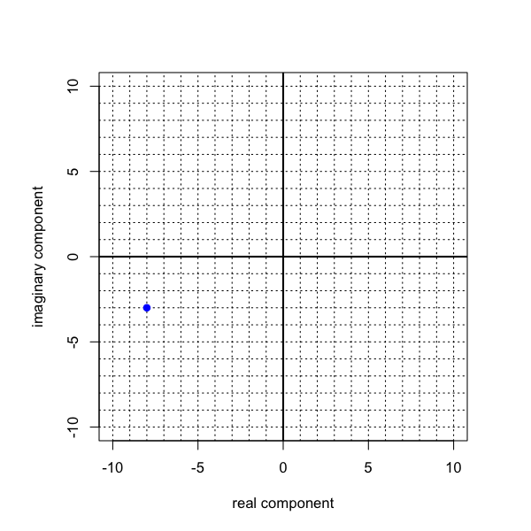

     Please **write the value of $z_1$** (in rectangular form: $a+bi$).

     *Type your answer precisely, with no spaces, using digits, “-”, “+”, and “i”. If the real term is nonzero, put it first. If either component is zero, do not include that term. If both components are zero, type “0” without the quotes. Instead of writing “1i” or “-1i” just write “i” or “-i”.*

#### Solution

#### Question

102. Let $z_1$ be a complex number with integer components. It is graphed on a [complex plane](https://en.wikipedia.org/wiki/Complex_plane) below.

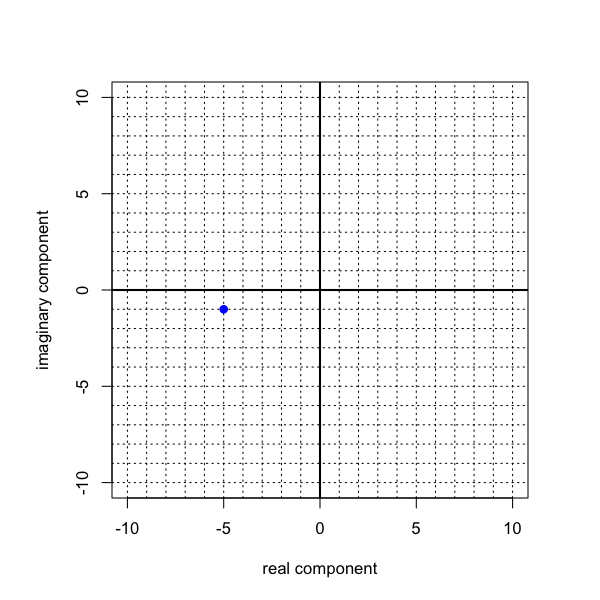

     Please **write the value of $z_1$** (in rectangular form: $a+bi$).

     *Type your answer precisely, with no spaces, using digits, “-”, “+”, and “i”. If the real term is nonzero, put it first. If either component is zero, do not include that term. If both components are zero, type “0” without the quotes. Instead of writing “1i” or “-1i” just write “i” or “-i”.*

#### Solution

#### Question

103. Let $z_1$ be a complex number with integer components. It is graphed on a [complex plane](https://en.wikipedia.org/wiki/Complex_plane) below.

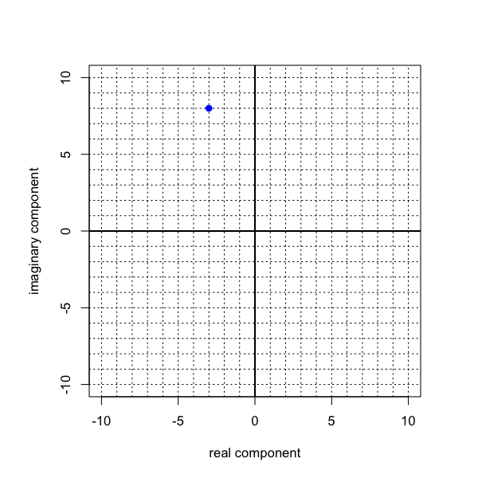

     Please **write the value of $z_1$** (in rectangular form: $a+bi$).

     *Type your answer precisely, with no spaces, using digits, “-”, “+”, and “i”. If the real term is nonzero, put it first. If either component is zero, do not include that term. If both components are zero, type “0” without the quotes. Instead of writing “1i” or “-1i” just write “i” or “-i”.*

#### Solution

#### Question

104. Let $z_1$ be a complex number with integer components. It is graphed on a [complex plane](https://en.wikipedia.org/wiki/Complex_plane) below.

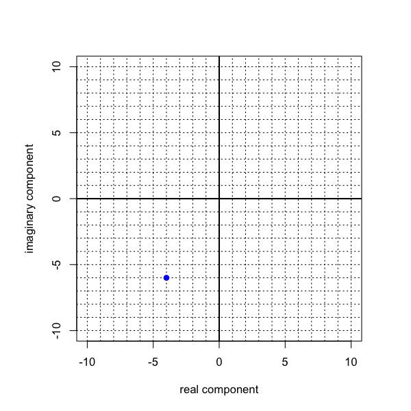

     Please **write the value of $z_1$** (in rectangular form: $a+bi$).

     *Type your answer precisely, with no spaces, using digits, “-”, “+”, and “i”. If the real term is nonzero, put it first. If either component is zero, do not include that term. If both components are zero, type “0” without the quotes. Instead of writing “1i” or “-1i” just write “i” or “-i”.*

#### Solution

#### Question

105. Let $z_1$ be a complex number with integer components. It is graphed on a [complex plane](https://en.wikipedia.org/wiki/Complex_plane) below.

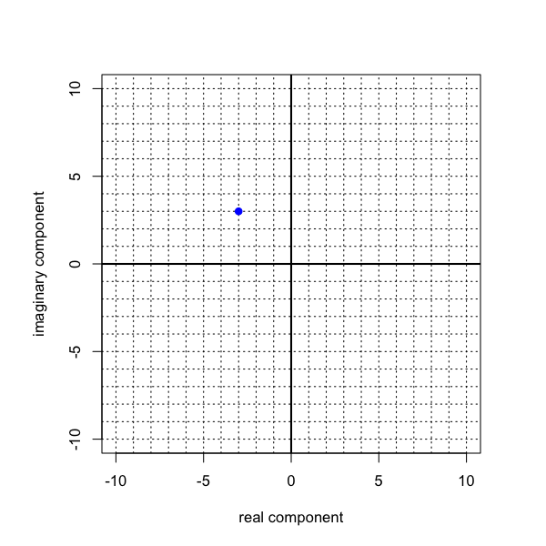

     Please **write the value of $z_1$** (in rectangular form: $a+bi$).

     *Type your answer precisely, with no spaces, using digits, “-”, “+”, and “i”. If the real term is nonzero, put it first. If either component is zero, do not include that term. If both components are zero, type “0” without the quotes. Instead of writing “1i” or “-1i” just write “i” or “-i”.*

#### Solution

#### Question

106. Let $z_1$ be a complex number with integer components. It is graphed on a [complex plane](https://en.wikipedia.org/wiki/Complex_plane) below.

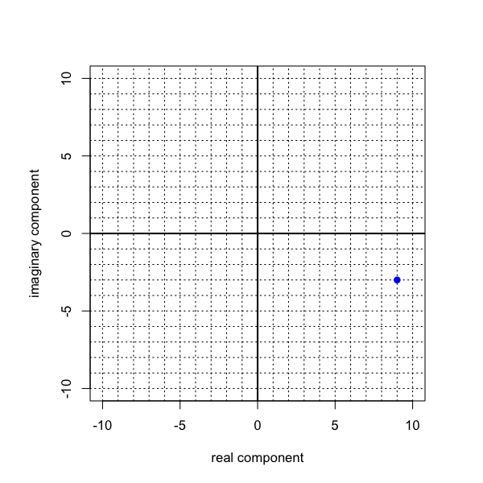

     Please **write the value of $z_1$** (in rectangular form: $a+bi$).

     *Type your answer precisely, with no spaces, using digits, “-”, “+”, and “i”. If the real term is nonzero, put it first. If either component is zero, do not include that term. If both components are zero, type “0” without the quotes. Instead of writing “1i” or “-1i” just write “i” or “-i”.*

#### Solution

#### Question

107. Let $z_1$ be a complex number with integer components. It is graphed on a [complex plane](https://en.wikipedia.org/wiki/Complex_plane) below.

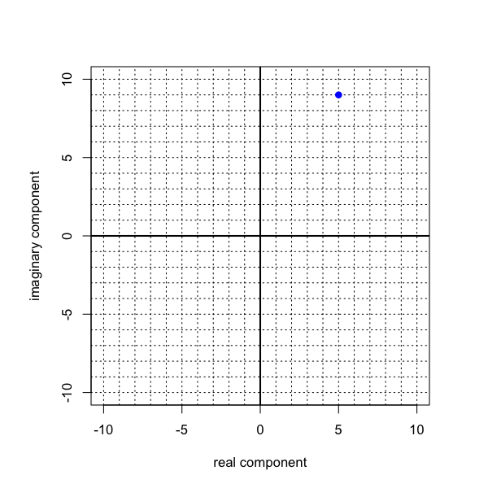

     Please **write the value of $z_1$** (in rectangular form: $a+bi$).

     *Type your answer precisely, with no spaces, using digits, “-”, “+”, and “i”. If the real term is nonzero, put it first. If either component is zero, do not include that term. If both components are zero, type “0” without the quotes. Instead of writing “1i” or “-1i” just write “i” or “-i”.*

#### Solution

#### Question

108. Let $z_1$ be a complex number with integer components. It is graphed on a [complex plane](https://en.wikipedia.org/wiki/Complex_plane) below.

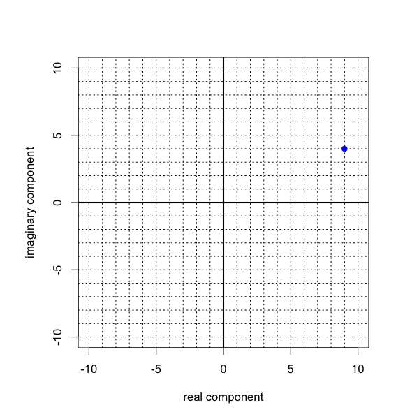

     Please **write the value of $z_1$** (in rectangular form: $a+bi$).

     *Type your answer precisely, with no spaces, using digits, “-”, “+”, and “i”. If the real term is nonzero, put it first. If either component is zero, do not include that term. If both components are zero, type “0” without the quotes. Instead of writing “1i” or “-1i” just write “i” or “-i”.*

#### Solution

#### Question

109. Let $z_1$ be a complex number with integer components. It is graphed on a [complex plane](https://en.wikipedia.org/wiki/Complex_plane) below.

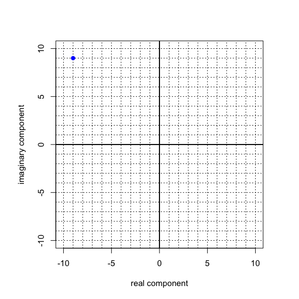

     Please **write the value of $z_1$** (in rectangular form: $a+bi$).

     *Type your answer precisely, with no spaces, using digits, “-”, “+”, and “i”. If the real term is nonzero, put it first. If either component is zero, do not include that term. If both components are zero, type “0” without the quotes. Instead of writing “1i” or “-1i” just write “i” or “-i”.*

#### Solution

#### Question

110. Let $z_1$ be a complex number with integer components. It is graphed on a [complex plane](https://en.wikipedia.org/wiki/Complex_plane) below.

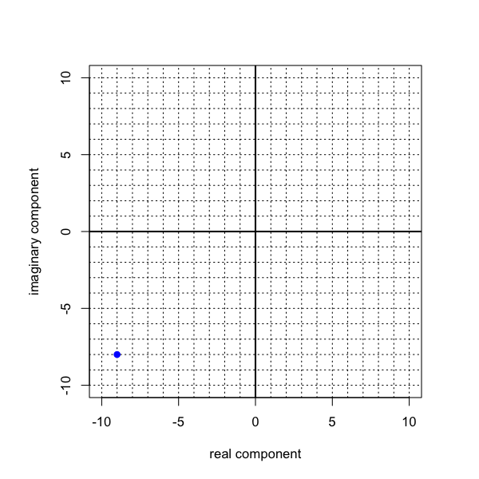

     Please **write the value of $z_1$** (in rectangular form: $a+bi$).

     *Type your answer precisely, with no spaces, using digits, “-”, “+”, and “i”. If the real term is nonzero, put it first. If either component is zero, do not include that term. If both components are zero, type “0” without the quotes. Instead of writing “1i” or “-1i” just write “i” or “-i”.*

#### Solution

#### Question

111. Let $z_1$ be a complex number with integer components. It is graphed on a [complex plane](https://en.wikipedia.org/wiki/Complex_plane) below, along with a segment connecting it to the origin.

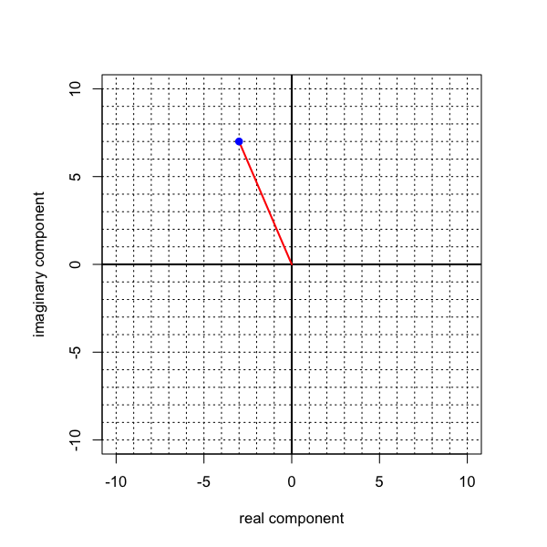

     The [modulus](https://en.wikipedia.org/wiki/Absolute_value#Complex_numbers) of a complex number is analogous to finding distance on a 2D Cartesian plane from the origin to a point. If complex number $z=a+bi$ then its modulus, $|z|$, is calculated with a variation on the distance formula:
     $$|z|=\sqrt{a^2+b^2}$$
     Calculate $|z_1|$. *The tolerance is $\pm 0.1$.*

#### Solution

#### Question

112. Let $z_1$ be a complex number with integer components. It is graphed on a [complex plane](https://en.wikipedia.org/wiki/Complex_plane) below, along with a segment connecting it to the origin.

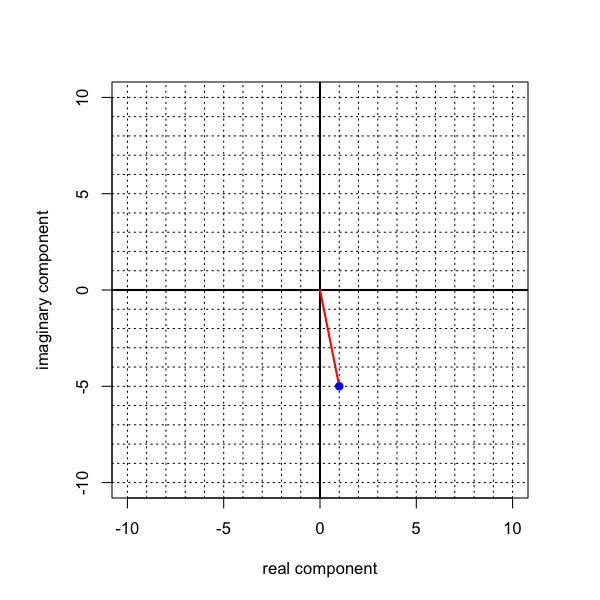

     The [modulus](https://en.wikipedia.org/wiki/Absolute_value#Complex_numbers) of a complex number is analogous to finding distance on a 2D Cartesian plane from the origin to a point. If complex number $z=a+bi$ then its modulus, $|z|$, is calculated with a variation on the distance formula:
     $$|z|=\sqrt{a^2+b^2}$$
     Calculate $|z_1|$. *The tolerance is $\pm 0.1$.*

#### Solution

#### Question

113. Let $z_1$ be a complex number with integer components. It is graphed on a [complex plane](https://en.wikipedia.org/wiki/Complex_plane) below, along with a segment connecting it to the origin.

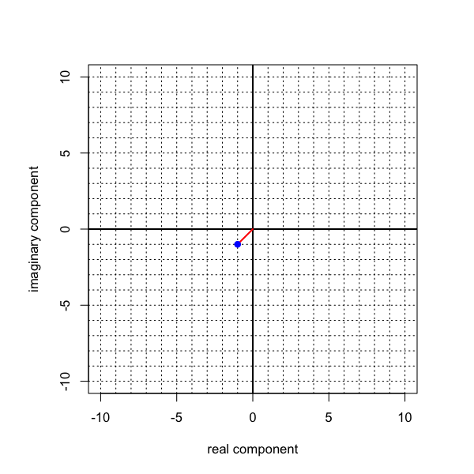

     The [modulus](https://en.wikipedia.org/wiki/Absolute_value#Complex_numbers) of a complex number is analogous to finding distance on a 2D Cartesian plane from the origin to a point. If complex number $z=a+bi$ then its modulus, $|z|$, is calculated with a variation on the distance formula:
     $$|z|=\sqrt{a^2+b^2}$$
     Calculate $|z_1|$. *The tolerance is $\pm 0.1$.*

#### Solution

#### Question

114. Let $z_1$ be a complex number with integer components. It is graphed on a [complex plane](https://en.wikipedia.org/wiki/Complex_plane) below, along with a segment connecting it to the origin.

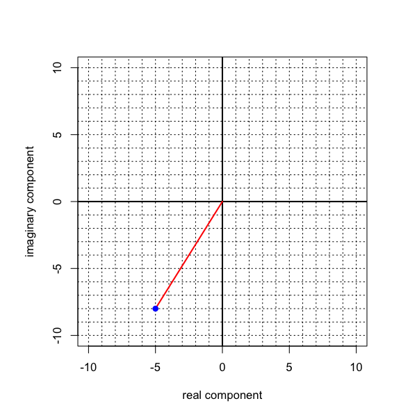

     The [modulus](https://en.wikipedia.org/wiki/Absolute_value#Complex_numbers) of a complex number is analogous to finding distance on a 2D Cartesian plane from the origin to a point. If complex number $z=a+bi$ then its modulus, $|z|$, is calculated with a variation on the distance formula:
     $$|z|=\sqrt{a^2+b^2}$$
     Calculate $|z_1|$. *The tolerance is $\pm 0.1$.*

#### Solution

#### Question

115. Let $z_1$ be a complex number with integer components. It is graphed on a [complex plane](https://en.wikipedia.org/wiki/Complex_plane) below, along with a segment connecting it to the origin.

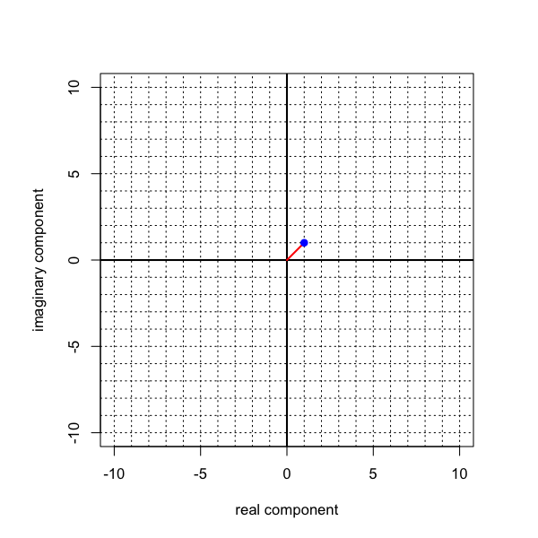

     The [modulus](https://en.wikipedia.org/wiki/Absolute_value#Complex_numbers) of a complex number is analogous to finding distance on a 2D Cartesian plane from the origin to a point. If complex number $z=a+bi$ then its modulus, $|z|$, is calculated with a variation on the distance formula:
     $$|z|=\sqrt{a^2+b^2}$$
     Calculate $|z_1|$. *The tolerance is $\pm 0.1$.*

#### Solution

#### Question

116. Let $z_1$ be a complex number with integer components. It is graphed on a [complex plane](https://en.wikipedia.org/wiki/Complex_plane) below, along with a segment connecting it to the origin.

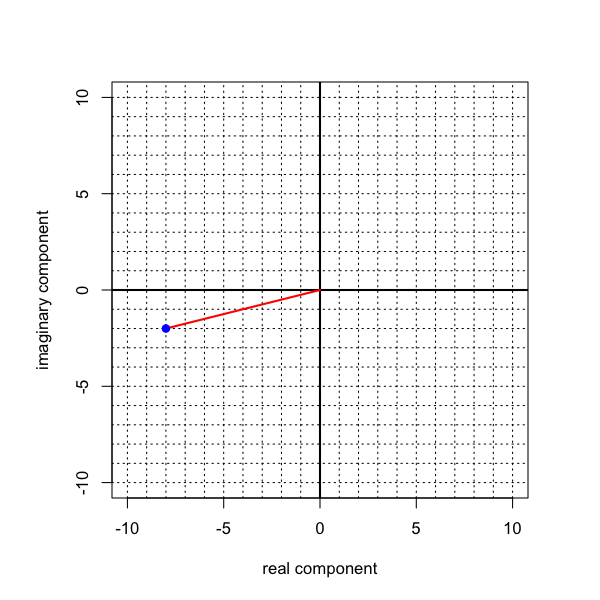

     The [modulus](https://en.wikipedia.org/wiki/Absolute_value#Complex_numbers) of a complex number is analogous to finding distance on a 2D Cartesian plane from the origin to a point. If complex number $z=a+bi$ then its modulus, $|z|$, is calculated with a variation on the distance formula:
     $$|z|=\sqrt{a^2+b^2}$$
     Calculate $|z_1|$. *The tolerance is $\pm 0.1$.*

#### Solution

#### Question

117. Let $z_1$ be a complex number with integer components. It is graphed on a [complex plane](https://en.wikipedia.org/wiki/Complex_plane) below, along with a segment connecting it to the origin.

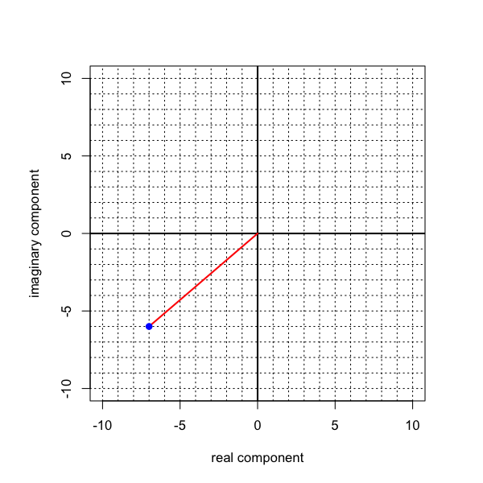

     The [modulus](https://en.wikipedia.org/wiki/Absolute_value#Complex_numbers) of a complex number is analogous to finding distance on a 2D Cartesian plane from the origin to a point. If complex number $z=a+bi$ then its modulus, $|z|$, is calculated with a variation on the distance formula:
     $$|z|=\sqrt{a^2+b^2}$$
     Calculate $|z_1|$. *The tolerance is $\pm 0.1$.*

#### Solution

#### Question

118. Let $z_1$ be a complex number with integer components. It is graphed on a [complex plane](https://en.wikipedia.org/wiki/Complex_plane) below, along with a segment connecting it to the origin.

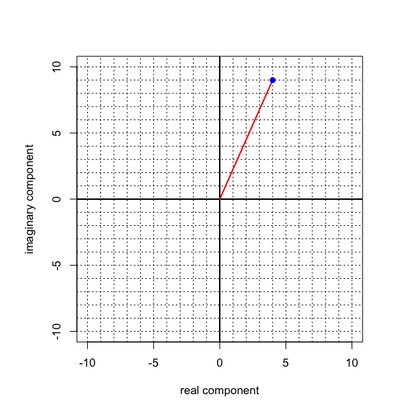

     The [modulus](https://en.wikipedia.org/wiki/Absolute_value#Complex_numbers) of a complex number is analogous to finding distance on a 2D Cartesian plane from the origin to a point. If complex number $z=a+bi$ then its modulus, $|z|$, is calculated with a variation on the distance formula:
     $$|z|=\sqrt{a^2+b^2}$$
     Calculate $|z_1|$. *The tolerance is $\pm 0.1$.*

#### Solution

#### Question

119. Let $z_1$ be a complex number with integer components. It is graphed on a [complex plane](https://en.wikipedia.org/wiki/Complex_plane) below, along with a segment connecting it to the origin.

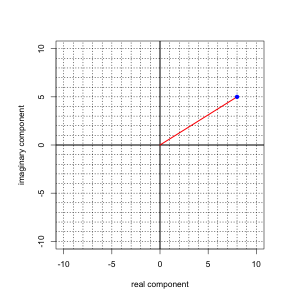

     The [modulus](https://en.wikipedia.org/wiki/Absolute_value#Complex_numbers) of a complex number is analogous to finding distance on a 2D Cartesian plane from the origin to a point. If complex number $z=a+bi$ then its modulus, $|z|$, is calculated with a variation on the distance formula:
     $$|z|=\sqrt{a^2+b^2}$$
     Calculate $|z_1|$. *The tolerance is $\pm 0.1$.*

#### Solution

#### Question

120. Let $z_1$ be a complex number with integer components. It is graphed on a [complex plane](https://en.wikipedia.org/wiki/Complex_plane) below, along with a segment connecting it to the origin.

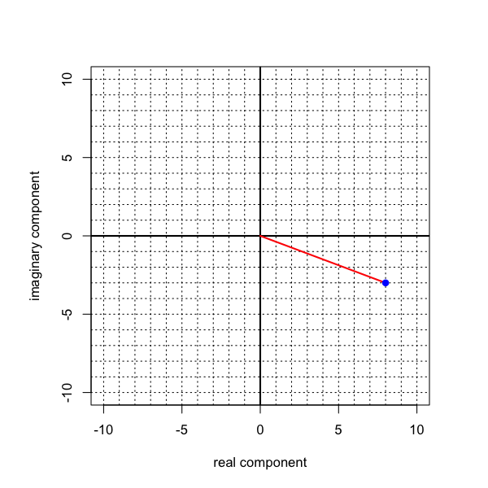

     The [modulus](https://en.wikipedia.org/wiki/Absolute_value#Complex_numbers) of a complex number is analogous to finding distance on a 2D Cartesian plane from the origin to a point. If complex number $z=a+bi$ then its modulus, $|z|$, is calculated with a variation on the distance formula:
     $$|z|=\sqrt{a^2+b^2}$$
     Calculate $|z_1|$. *The tolerance is $\pm 0.1$.*

#### Solution

#### Question

121. Let $z_1$ be a complex number with integer components. It is graphed on a [complex plane](https://en.wikipedia.org/wiki/Complex_plane) below. The argument is the standard angle indicated with $\theta$.

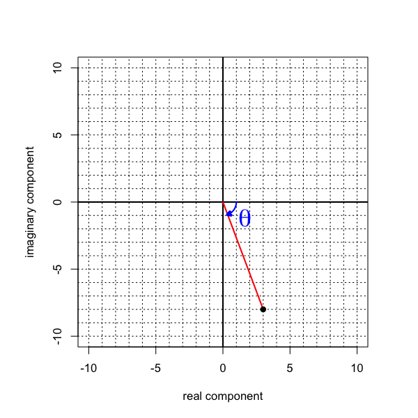

     The argument can be found using the [atan2](https://en.wikipedia.org/wiki/Atan2) function. Find the angle (the argument) of $z_1$ in [radians](https://en.wikipedia.org/wiki/Radian) between $-\pi$ and $\pi$. A negative angle indicates a clockwise rotation from East, and a positive angle indicates a counter-clockwise rotation from East.

     *The tolerance is $\pm0.01$.*

#### Solution

#### Question

122. Let $z_1$ be a complex number with integer components. It is graphed on a [complex plane](https://en.wikipedia.org/wiki/Complex_plane) below. The argument is the standard angle indicated with $\theta$.

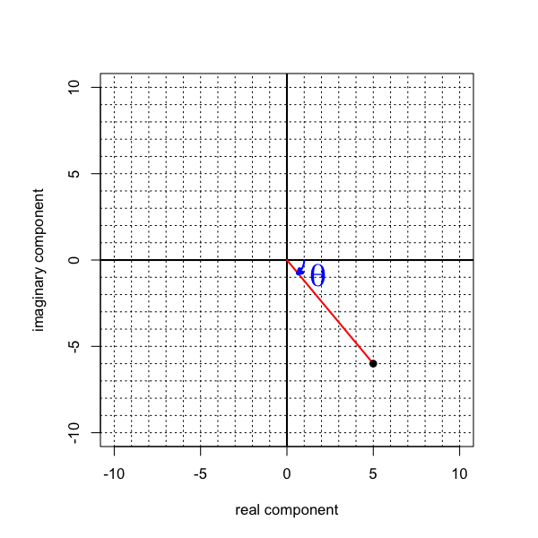

     The argument can be found using the [atan2](https://en.wikipedia.org/wiki/Atan2) function. Find the angle (the argument) of $z_1$ in [radians](https://en.wikipedia.org/wiki/Radian) between $-\pi$ and $\pi$. A negative angle indicates a clockwise rotation from East, and a positive angle indicates a counter-clockwise rotation from East.

     *The tolerance is $\pm0.01$.*

#### Solution

#### Question

123. Let $z_1$ be a complex number with integer components. It is graphed on a [complex plane](https://en.wikipedia.org/wiki/Complex_plane) below. The argument is the standard angle indicated with $\theta$.

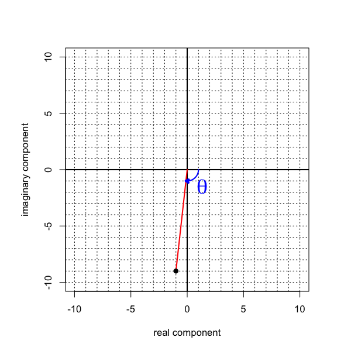

     The argument can be found using the [atan2](https://en.wikipedia.org/wiki/Atan2) function. Find the angle (the argument) of $z_1$ in [radians](https://en.wikipedia.org/wiki/Radian) between $-\pi$ and $\pi$. A negative angle indicates a clockwise rotation from East, and a positive angle indicates a counter-clockwise rotation from East.

     *The tolerance is $\pm0.01$.*

#### Solution

#### Question

124. Let $z_1$ be a complex number with integer components. It is graphed on a [complex plane](https://en.wikipedia.org/wiki/Complex_plane) below. The argument is the standard angle indicated with $\theta$.

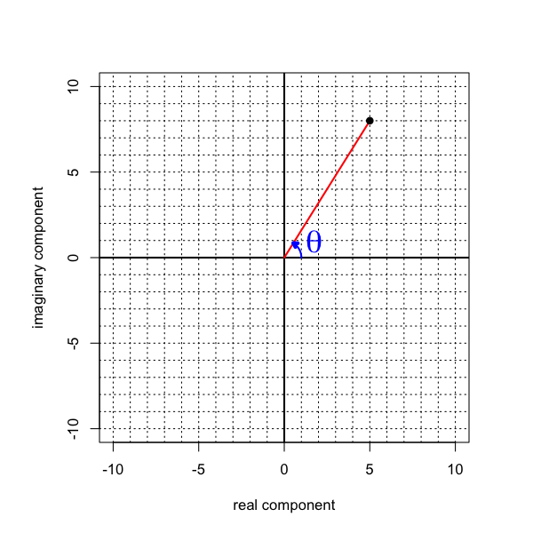

     The argument can be found using the [atan2](https://en.wikipedia.org/wiki/Atan2) function. Find the angle (the argument) of $z_1$ in [radians](https://en.wikipedia.org/wiki/Radian) between $-\pi$ and $\pi$. A negative angle indicates a clockwise rotation from East, and a positive angle indicates a counter-clockwise rotation from East.

     *The tolerance is $\pm0.01$.*

#### Solution

#### Question

125. Let $z_1$ be a complex number with integer components. It is graphed on a [complex plane](https://en.wikipedia.org/wiki/Complex_plane) below. The argument is the standard angle indicated with $\theta$.

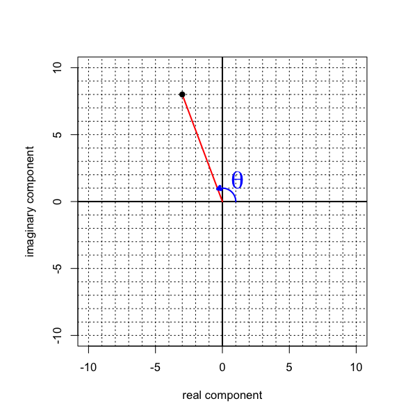

     The argument can be found using the [atan2](https://en.wikipedia.org/wiki/Atan2) function. Find the angle (the argument) of $z_1$ in [radians](https://en.wikipedia.org/wiki/Radian) between $-\pi$ and $\pi$. A negative angle indicates a clockwise rotation from East, and a positive angle indicates a counter-clockwise rotation from East.

     *The tolerance is $\pm0.01$.*

#### Solution

#### Question

126. Let $z_1$ be a complex number with integer components. It is graphed on a [complex plane](https://en.wikipedia.org/wiki/Complex_plane) below. The argument is the standard angle indicated with $\theta$.

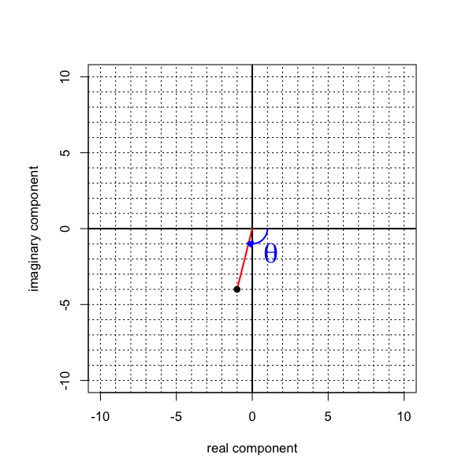

     The argument can be found using the [atan2](https://en.wikipedia.org/wiki/Atan2) function. Find the angle (the argument) of $z_1$ in [radians](https://en.wikipedia.org/wiki/Radian) between $-\pi$ and $\pi$. A negative angle indicates a clockwise rotation from East, and a positive angle indicates a counter-clockwise rotation from East.

     *The tolerance is $\pm0.01$.*

#### Solution

#### Question

127. Let $z_1$ be a complex number with integer components. It is graphed on a [complex plane](https://en.wikipedia.org/wiki/Complex_plane) below. The argument is the standard angle indicated with $\theta$.

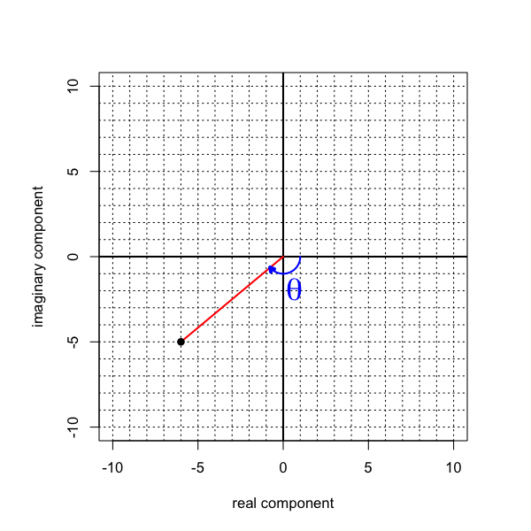

     The argument can be found using the [atan2](https://en.wikipedia.org/wiki/Atan2) function. Find the angle (the argument) of $z_1$ in [radians](https://en.wikipedia.org/wiki/Radian) between $-\pi$ and $\pi$. A negative angle indicates a clockwise rotation from East, and a positive angle indicates a counter-clockwise rotation from East.

     *The tolerance is $\pm0.01$.*

#### Solution

#### Question

128. Let $z_1$ be a complex number with integer components. It is graphed on a [complex plane](https://en.wikipedia.org/wiki/Complex_plane) below. The argument is the standard angle indicated with $\theta$.

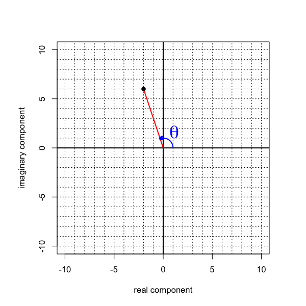

     The argument can be found using the [atan2](https://en.wikipedia.org/wiki/Atan2) function. Find the angle (the argument) of $z_1$ in [radians](https://en.wikipedia.org/wiki/Radian) between $-\pi$ and $\pi$. A negative angle indicates a clockwise rotation from East, and a positive angle indicates a counter-clockwise rotation from East.

     *The tolerance is $\pm0.01$.*

#### Solution

#### Question

129. Let $z_1$ be a complex number with integer components. It is graphed on a [complex plane](https://en.wikipedia.org/wiki/Complex_plane) below. The argument is the standard angle indicated with $\theta$.

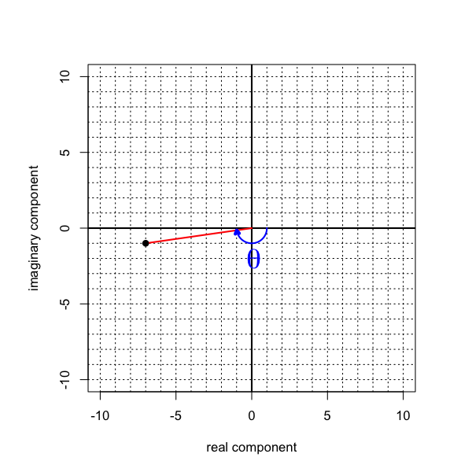

     The argument can be found using the [atan2](https://en.wikipedia.org/wiki/Atan2) function. Find the angle (the argument) of $z_1$ in [radians](https://en.wikipedia.org/wiki/Radian) between $-\pi$ and $\pi$. A negative angle indicates a clockwise rotation from East, and a positive angle indicates a counter-clockwise rotation from East.

     *The tolerance is $\pm0.01$.*

#### Solution

#### Question

130. Let $z_1$ be a complex number with integer components. It is graphed on a [complex plane](https://en.wikipedia.org/wiki/Complex_plane) below. The argument is the standard angle indicated with $\theta$.

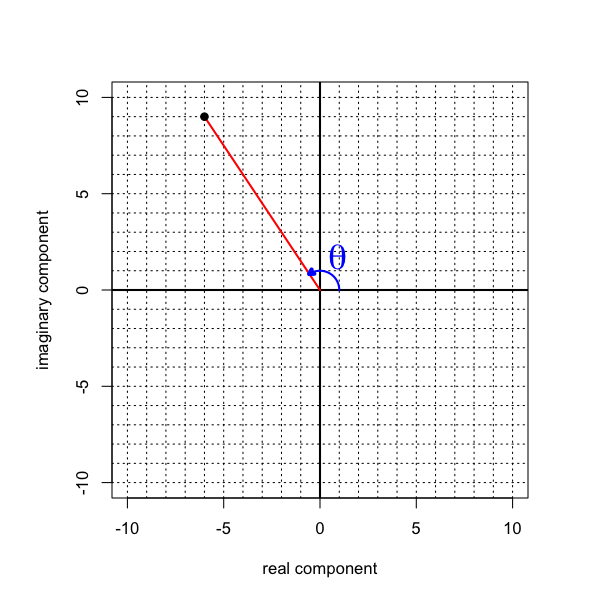

     The argument can be found using the [atan2](https://en.wikipedia.org/wiki/Atan2) function. Find the angle (the argument) of $z_1$ in [radians](https://en.wikipedia.org/wiki/Radian) between $-\pi$ and $\pi$. A negative angle indicates a clockwise rotation from East, and a positive angle indicates a counter-clockwise rotation from East.

     *The tolerance is $\pm0.01$.*

#### Solution

#### Question

131. Let $z_1$ be a [complex number](https://en.wikipedia.org/wiki/Complex_number#Polar_complex_plane) with modulus $r=7.28$ and argument $\theta=1.849$ radians. **Express $z_1$ in rectangular form ($a+bi$).**

     The following formulas will be useful:
     $$a = r\cos(\theta)$$
     $$b = r\sin(\theta)$$

     To visualize, $z_1$ is graphed on a [complex plane](https://en.wikipedia.org/wiki/Complex_plane) below.

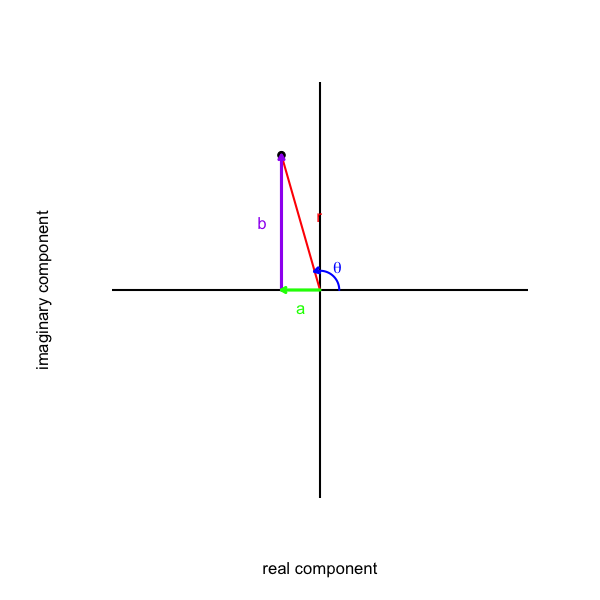

     Please round the components to the nearest integer.